# R语言机器学习之caret包运用

situ

2017年6月14日

全面的用法参考：[caret](http://topepo.github.io/caret/).

### 读取数据

- 转换原则:

| transform | meaning |
| --- | --- |
| 6–→NA | Not answer |
| 0–→4,5 | I have never experienced & I do not know what this is |
| 1–→3 | I have experienced this X years before |
| 2–→2 | I have experienced this past 12 MONTH |
| 3–→1 | I am currently experiencing |

```r
sym = read.csv("C:/Users/situ.st.1/Desktop/SituXueying/6.13/symptom and VAS_shortname.csv")
sym = as.data.frame(sym)
sym = sym[,c(1:46,93,94,96,119)]
dim(sym)
```

```
## [1] 320  50
```

```r
head(sym[,1:10])
```

```
##   expmoaa expmoab expmoac expmoad expmoae expmoaf expmoag expmoah expmoai
## 1       2       2       4       2       5       5       4       4       2
## 2       4       4       4       4       4       4       4       4       4
## 3       4       4       4       2       5       5       4       4       4
## 4       3       4       3       4       4       4       4       4       3
## 5       4       4       4       2       5       5       2       5       4
## 6       2       4       4       2       4       4       1       4       2
##   expmoaj
## 1       1
## 2       4
## 3       1
## 4       1
## 5       4
## 6       1
```

```r
sym[,1:46][sym[,1:46]==6] = NA
sym[,1:46][sym[,1:46]==4] = 0
sym[,1:46][sym[,1:46]==5] = 0
sym[,1:46][sym[,1:46]==3] = 7
sym[,1:46][sym[,1:46]==1] = 3
sym[,1:46][sym[,1:46]==7] = 1
head(sym[,1:10])
```

```
##   expmoaa expmoab expmoac expmoad expmoae expmoaf expmoag expmoah expmoai
## 1       2       2       0       2       0       0       0       0       2
## 2       0       0       0       0       0       0       0       0       0
## 3       0       0       0       2       0       0       0       0       0
## 4       1       0       1       0       0       0       0       0       1
## 5       0       0       0       2       0       0       2       0       0
## 6       2       0       0       2       0       0       3       0       2
##   expmoaj
## 1       3
## 2       0
## 3       3
## 4       3
## 5       0
## 6       3
```

```r
y = dim(sym)[2]
head(sym[,41:y])
```

```
##   expmobo expmobp expmobq expmobr expmobs expmobt sexresp ageres nageres
## 1       0       2       2       0       3       0       2      3      50
## 2       0       0       0       0       0       2       2      2      33
## 3       3       3       3       0       2       0       1      2      31
## 4       3       0       3       0       3       0       2      2      38
## 5       2       2       2       0       0       2       1      1      20
## 6       0       0       3       2       2       2       2      2      33
##   vas_4
## 1     0
## 2     0
## 3     1
## 4     0
## 5     0
## 6     1
```

### 数据预处理

#### 初步降维

1. **nearZeroVar**：删除常数自变量，或者是方差极小的自变量。 主要参数说明： freqCut:认为0方差的阈值，默认值为95/5，即最频繁的数值个数除以次频繁的数值个数； saveMetrics:逻辑值，默认为False，如果为True的话会返回一个统计表，反映每个变量是否为零方差和近零方差； names:逻辑值，默认为False，如果为True的话，返回零方差和近零方差的变量名，否则返回对应的索引值
2. **findcorrelation**：删除与其它自变量有很强相关性的变量。 主要参数说明： cutoff:指定高度线性相关的临界值，默认为0.9； verbose:逻辑值，指定是否打印出函数运算的详细结果； names:逻辑值，是否返回变量名，默认返回需要删除变量的对应索引值； exact:逻辑值，是否重新计算每一步的平均相关系数
3. **findLinearCombos**：删除多重共线性变量

```r
library(caret)
y = dim(sym)[2]
n1 = nearZeroVar(sym,freqCut = 20) #21
n2 = findCorrelation(cor(sym[,-c(y-1,y)]), 0.7)
n3 = findLinearCombos(sym[,-c(y-1,y)])
n1;n2;n3;
```

```
## [1] 21
```

```
## integer(0)
```

```
## $linearCombos
## list()
##
## $remove
## NULL
```

```r
sym1 = sym[,-c(n1,n2)] #5051 id
dim(sym1)
```

```
## [1] 320  49
```

```r
y = dim(sym1)[2]
sym1[,y] = as.factor(sym1[,y])
```

#### 图形观察

- **featherPlot**用于在建模前还可以对样本数据进行图形观察,画图类型有 box, density, pairs等.对于回归可用pairs or scatter

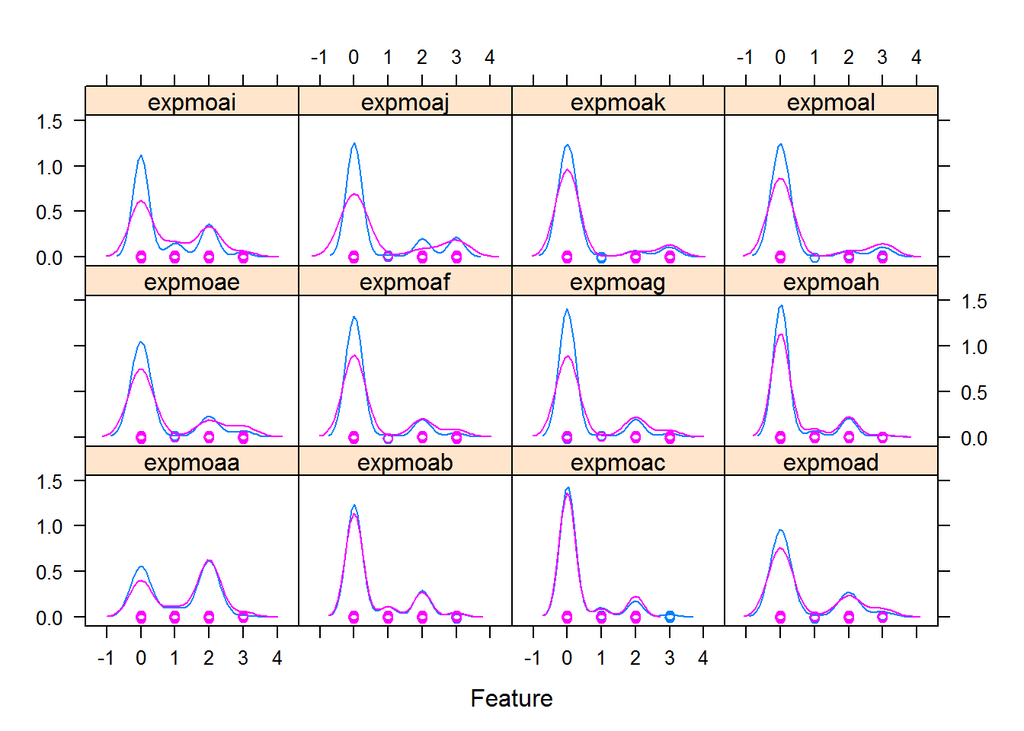

```r
featurePlot(sym1[,1:12],sym1[,y],plot="density")
```

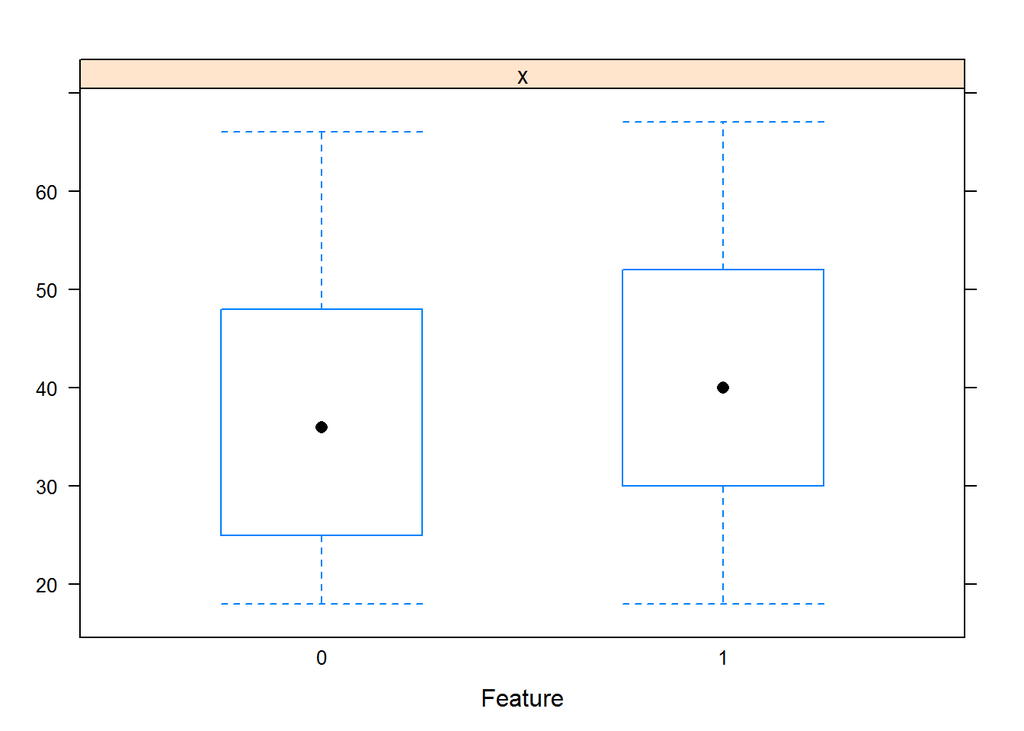

```r
featurePlot(sym1$nageres,sym1[,y],plot = "box")
```

#### 缺失值处理

- **preProcess**提供了三种缺失值填补的方法，即K近邻方法“knnImpute”、Bagging树集成方法“bagImpute”,和中位数法。
- K近邻方法:会对原始数据进行标准化，如果需要返回原始值，还需将标准化公式倒推回来；
- Bagging树集成方法:理论上对缺失值的填补更权威，但其效率比较低；
- 中位数方法:速度非常快，但填补的准确率有待验证。

```r
Process = preProcess(sym1)
sym2 = predict(Process, sym1)
```

### 特征选择

1. 特征选择：在进行数据挖掘时，我们并不需要将所有的自变量用来建模，而是从中选择若干最重要的变量。
2. 目前关于特征选择的方法主要有两大类，即封装法和过滤法： **封装法(Wrapper)**将特征选择过程与训练过程融合在一起，以模型的**预测能力**作为特征选择的衡量标准,速度较慢。（如逐步回归） **过滤法(Filter)**特征选择过程与训练过程相互独立，通过分析变量内部的关系进行筛选操作，与训练模型的选择并没有关系，速度快，但可能会删除非常有实质意义的变量。（如通过变量间的相关性、近零方差检验、聚类分析等方法选择变量）过滤法可以使用caret包中的**sbf**(select by filter)函数实现
3. caret包中提供的封装法主要有3种，即递归特征删减法、遗传算法和蚁群算法。三种方法实现的函数分别是**rfe***,gafs和safs

```r
set.seed(1996)# "expmoan" "expmoam" "expmoap" "expmoao" "expmobf"
subsets =  seq(5,30,5)
ctrl= rfeControl(functions = rfFuncs, #rfFuncs（随机森林），lmFuncs（线性回归），nbFuncs（朴素贝叶斯），treebagFuncs（装袋决策树）
                 method = "cv",#cv（交叉检验）, boot（提升），LOOCV（留一）
                 verbose = FALSE, #是否返回每次重抽样的详细信息，默认为FALSE。
                 returnResamp = "final")#返回重抽样的汇总信息
Profile = rfe(x=sym1[,1:(y-1)], y=sym1[,y],sizes = subsets,rfeControl = ctrl)
```

```r
Profile
```

```
##
## Recursive feature selection
##
## Outer resampling method: Cross-Validated (10 fold)
##
## Resampling performance over subset size:
##
##  Variables Accuracy   Kappa AccuracySD KappaSD Selected
##          5   0.6223 0.18348    0.07445 0.15874        *
##         10   0.5977 0.15149    0.07489 0.17442
##         15   0.5939 0.14010    0.06758 0.14113
##         20   0.5848 0.12037    0.06408 0.12341
##         25   0.6099 0.17686    0.05539 0.10519
##         30   0.6007 0.15219    0.05987 0.11738
##         48   0.5788 0.09387    0.05202 0.09063
##
## The top 5 variables (out of 5):
##    expmoan, expmobf, expmoam, expmoao, expmoap
```

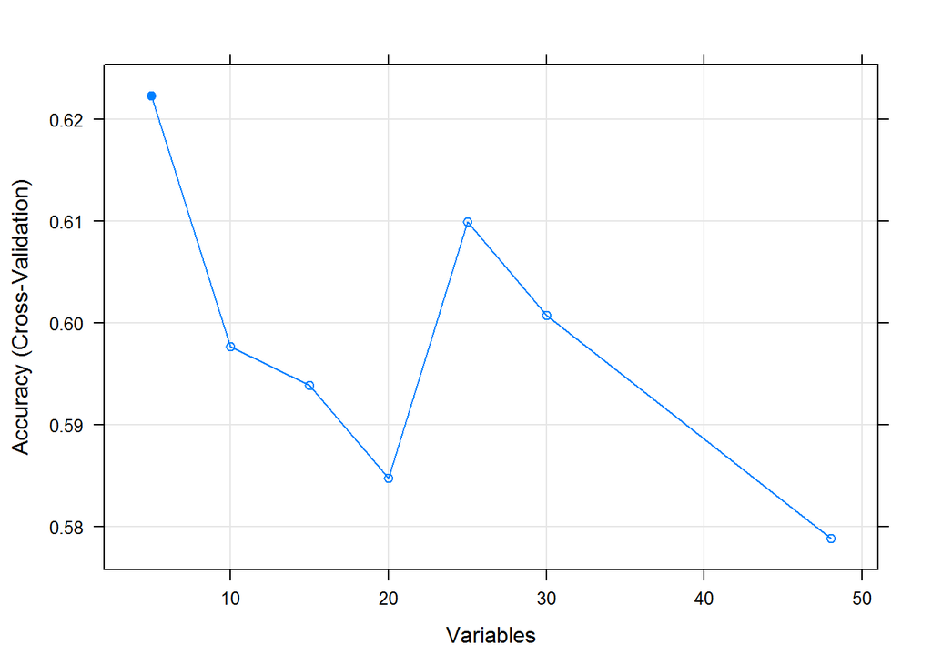

```r
plot(Profile, type = c('g','o'))
```

```r
Profile$optVariables
```

```
## [1] "expmoan" "expmobf" "expmoam" "expmoao" "expmoap"
```

### 建模与优化

- 首先得到经过特征选择后的样本数据，并划分为训练样本和检验样本

```r
y = dim(sym1)[2]
sub <- createDataPartition(sym1[,y],p=0.67,list=FALSE)
sym2 = data.frame(sym1[,Profile$optVariables],sym1$vas_4)
# sym2 = sym1[,-50]
y = dim(sym2)[2]
levels(sym2[,y]) = make.names(levels(sym2[,y]))

DATAT<- sym2[sub,]
DATA <- sym2[-sub,]
nrow(DATAT)
```

```
## [1] 216
```

```r
nrow(DATA)
```

```
## [1] 104
```

```r
y = dim(DATAT)[2]
```

- **trainControl** 定义模型训练参数
- **expand.gird**网格搜索, 如果要改用随机搜索则search = “random”。主要参数：迭代次数(n.trees)，学习速率(shrinkage)，决策树的深度(interaction.depth)
- **train**训练模型使用的方法为gbm（提升决策树）

```r
set.seed(1994)
fitControl = trainControl(method = "repeatedcv", #多次交叉检验
                          number = 10, #10折交叉验证
                          repeats = 5,#反复次数
                          returnResamp = "all",#返回重抽样的汇总信息
                          classProbs = TRUE,#获得重抽样中预测的类概率
                          summaryFunction = twoClassSummary)
                          #计算敏感度，特异性和ROC曲线下的面积
gbmGrid = expand.grid(.interaction.depth = c(1,3), #树深
                      .n.trees = c(100,500,1000,1500,2000,2500,3000,4000),#迭代次数
                      .shrinkage = c(0.001,0.005,0.01),#学习速度
                      .n.minobsinnode = 10)#训练样本的最少个数

gbmFit1 = train(x=DATAT[,-y],y = DATAT[,y],
                method = "gbm",
                trControl = fitControl,
                tuneGrid = gbmGrid,
                verbose = FALSE,
                metric = "ROC")
#评价模型标准：回归使用RMSE和R2，而分类使用Accuracy和Kappa统计量和ROC
```

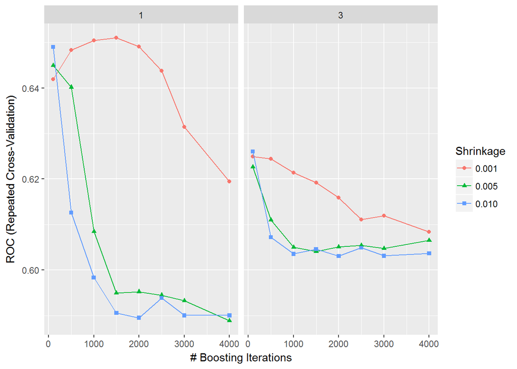

```r
# plot(gbmFit1)
ggplot(gbmFit1)
```

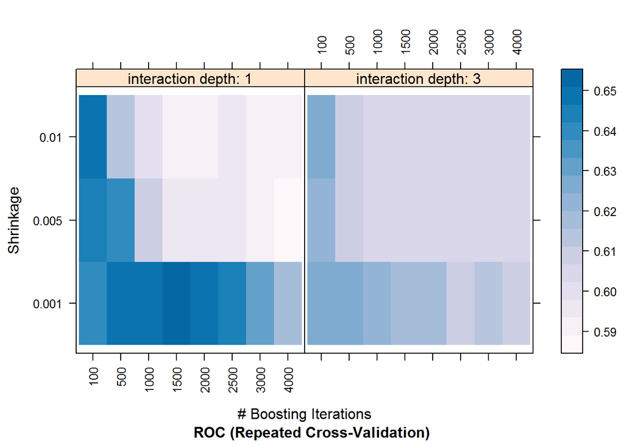

```r
trellis.par.set(caretTheme())
plot(gbmFit1, metric = "ROC", plotType = "level",
     scales = list(x = list(rot = 90))) #热力图
```

```r
gbmFit1
```

```
## Stochastic Gradient Boosting
##
## 216 samples
##   5 predictor
##   2 classes: 'X0', 'X1'
##
## No pre-processing
## Resampling: Cross-Validated (10 fold, repeated 5 times)
## Summary of sample sizes: 194, 194, 195, 195, 194, 194, ...
## Resampling results across tuning parameters:
##
##   shrinkage  interaction.depth  n.trees  ROC        Sens       Spec
##   0.001      1                   100     0.6418661  1.0000000  0.00000000
##   0.001      1                   500     0.6483191  0.9858974  0.03555556
##   0.001      1                  1000     0.6504558  0.8671795  0.17333333
##   0.001      1                  1500     0.6510114  0.8224359  0.24444444
##   0.001      1                  2000     0.6490741  0.7988462  0.28666667
##   0.001      1                  2500     0.6437749  0.7832051  0.31777778
##   0.001      1                  3000     0.6314530  0.7783333  0.34222222
##   0.001      1                  4000     0.6194587  0.7673077  0.36444444
##   0.001      3                   100     0.6249288  1.0000000  0.00000000
##   0.001      3                   500     0.6244444  0.9346154  0.09777778
##   0.001      3                  1000     0.6214103  0.7925641  0.24888889
##   0.001      3                  1500     0.6192023  0.7721795  0.35111111
##   0.001      3                  2000     0.6158547  0.7641026  0.38000000
##   0.001      3                  2500     0.6110399  0.7575641  0.40000000
##   0.001      3                  3000     0.6119373  0.7434615  0.39555556
##   0.001      3                  4000     0.6083903  0.7450000  0.39555556
##   0.005      1                   100     0.6449288  0.9811538  0.04666667
##   0.005      1                   500     0.6401709  0.7830769  0.32444444
##   0.005      1                  1000     0.6084330  0.7592308  0.37777778
##   0.005      1                  1500     0.5949573  0.7447436  0.36666667
##   0.005      1                  2000     0.5952422  0.7294872  0.38000000
##   0.005      1                  2500     0.5944872  0.7242308  0.37555556
##   0.005      1                  3000     0.5932479  0.7261538  0.37555556
##   0.005      1                  4000     0.5888462  0.7178205  0.37555556
##   0.005      3                   100     0.6226781  0.9269231  0.09777778
##   0.005      3                   500     0.6109829  0.7546154  0.38666667
##   0.005      3                  1000     0.6050142  0.7448718  0.38222222
##   0.005      3                  1500     0.6040598  0.7542308  0.36666667
```

[output cut: 10 more lines]

```
##   0.010      1                  3000     0.5900285  0.7214103  0.36888889
##   0.010      1                  4000     0.5900142  0.7370513  0.35111111
##   0.010      3                   100     0.6260256  0.7970513  0.24666667
##   0.010      3                   500     0.6071937  0.7484615  0.36888889
##   0.010      3                  1000     0.6035328  0.7653846  0.35333333
##   0.010      3                  1500     0.6045869  0.7730769  0.34444444
##   0.010      3                  2000     0.6030627  0.7774359  0.33777778
##   0.010      3                  2500     0.6049288  0.7824359  0.35333333
##   0.010      3                  3000     0.6031054  0.7855128  0.35111111
##   0.010      3                  4000     0.6036610  0.7919231  0.36444444
##
## Tuning parameter 'n.minobsinnode' was held constant at a value of 10
## ROC was used to select the optimal model using  the largest value.
## The final values used for the model were n.trees = 1500,
##  interaction.depth = 1, shrinkage = 0.001 and n.minobsinnode = 10.
```

```r
gbmFit1$bestTune #最优参数
```

```
##   n.trees interaction.depth shrinkage n.minobsinnode
## 4    1500                 1     0.001             10
```

### 模型比较

#### 建立径向核函数SVM模型

- 径向核函数：分类边界为非线性，近似圆形
- C为能够容忍的穿过间隔距离的观测数目和严重程度，C越小，越容易出现过拟合现象
- sigma 越大，分类边界越非线性，越容易出现过拟合现象

```r
set.seed(1994)
svmGrid1 = expand.grid(C = c(0.001,0.005,0.01,0.05,0.1),sigma = c(0.01,0.1,0.5,1,3))
svmFit1 <- train(x=DATAT[,-y],y = DATAT[,y],
                 method = "svmRadial", #径向核函数
                 trControl = fitControl,
                 tuneLength = 8,
                 verbose = FALSE,
                 metric = "ROC",
                 tuneGrid = svmGrid1)
```

[output not shown]

```r
svmFit1
```

```
## Support Vector Machines with Radial Basis Function Kernel
##
## 216 samples
##   5 predictor
##   2 classes: 'X0', 'X1'
##
## No pre-processing
## Resampling: Cross-Validated (10 fold, repeated 5 times)
## Summary of sample sizes: 194, 194, 195, 195, 194, 194, ...
## Resampling results across tuning parameters:
##
##   C      sigma  ROC        Sens       Spec
##   0.001  0.01   0.6299501  0.9060256  0.1066667
##   0.001  0.10   0.6377849  0.7974359  0.3355556
##   0.001  0.50   0.6303917  0.7825641  0.3777778
##   0.001  1.00   0.6272863  0.7683333  0.3488889
##   0.001  3.00   0.6237963  0.8607692  0.2600000
##   0.005  0.01   0.6431410  0.8351282  0.2600000
##   0.005  0.10   0.6017877  0.7978205  0.3000000
##   0.005  0.50   0.6437963  0.7967949  0.3422222
##   0.005  1.00   0.6308903  0.8129487  0.3333333
##   0.005  3.00   0.6300499  0.8374359  0.2311111
##   0.010  0.01   0.6291809  0.8155128  0.2777778
##   0.010  0.10   0.6272436  0.7894872  0.3066667
##   0.010  0.50   0.6480840  0.7839744  0.3733333
##   0.010  1.00   0.6310755  0.7982051  0.3244444
##   0.010  3.00   0.6276140  0.8428205  0.3066667
##   0.050  0.01   0.6190100  0.8230769  0.2733333
##   0.050  0.10   0.6271581  0.8035897  0.3111111
##   0.050  0.50   0.6458903  0.8064103  0.3200000
##   0.050  1.00   0.6287536  0.7726923  0.3622222
##   0.050  3.00   0.6287821  0.8151282  0.2822222
##   0.100  0.01   0.6232123  0.8276923  0.2622222
##   0.100  0.10   0.6281838  0.8002564  0.3422222
##   0.100  0.50   0.6525855  0.7596154  0.4177778
##   0.100  1.00   0.6207764  0.7962821  0.3333333
##   0.100  3.00   0.6350783  0.8415385  0.2911111
##
## ROC was used to select the optimal model using  the largest value.
## The final values used for the model were sigma = 0.5 and C = 0.1.
```

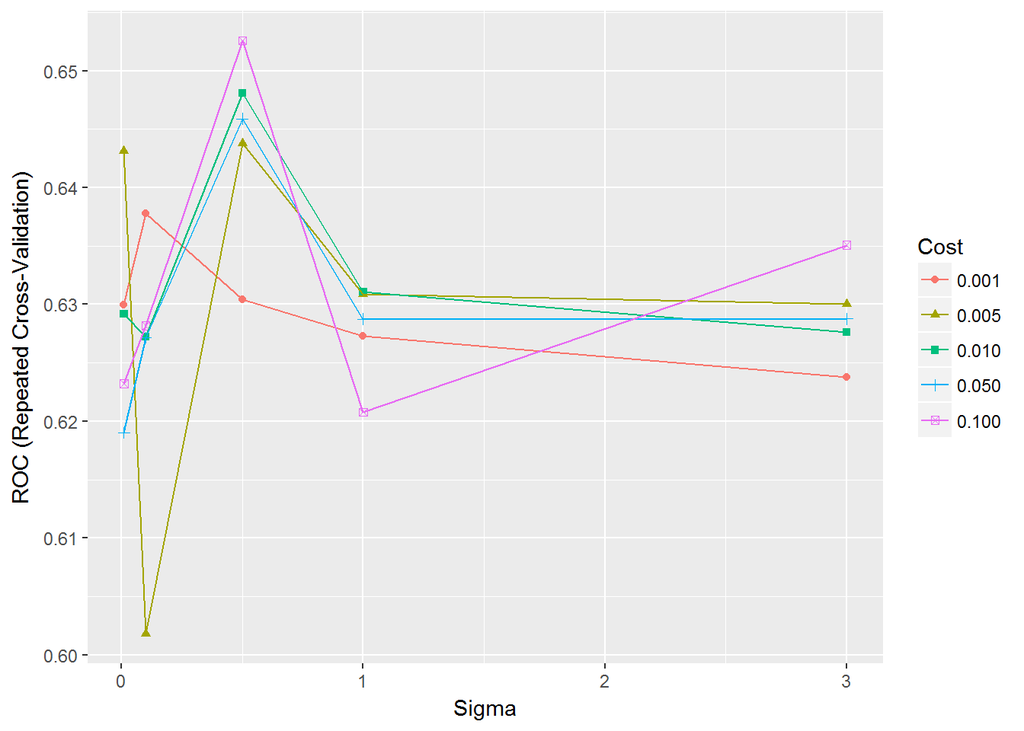

```r
ggplot(svmFit1)
```

#### 建立线性核函数SVM模型

- 线性核函数：分类边界为线性

```r
set.seed(1994)
svmGrid2 = expand.grid(C = c(0.001,0.005,0.01,0.05,0.1))
svmFit2 <- train(x=DATAT[,-y],y = DATAT[,y],
                 method = "svmLinear",
                 trControl = fitControl,
                 tuneLength = 8,
                 verbose = FALSE,
                 metric = "ROC",
                 tuneGrid = svmGrid2)
svmFit2
```

```
## Support Vector Machines with Linear Kernel
##
## 216 samples
##   5 predictor
##   2 classes: 'X0', 'X1'
##
## No pre-processing
## Resampling: Cross-Validated (10 fold, repeated 5 times)
## Summary of sample sizes: 194, 194, 195, 195, 194, 194, ...
## Resampling results across tuning parameters:
##
##   C      ROC        Sens       Spec
##   0.001  0.6052564  0.8260256  0.2600000
##   0.005  0.6088462  0.8397436  0.2244444
##   0.010  0.6253348  0.8464103  0.2244444
##   0.050  0.6057051  0.8383333  0.2222222
##   0.100  0.6001781  0.8589744  0.2244444
##
## ROC was used to select the optimal model using  the largest value.
## The final value used for the model was C = 0.01.
```

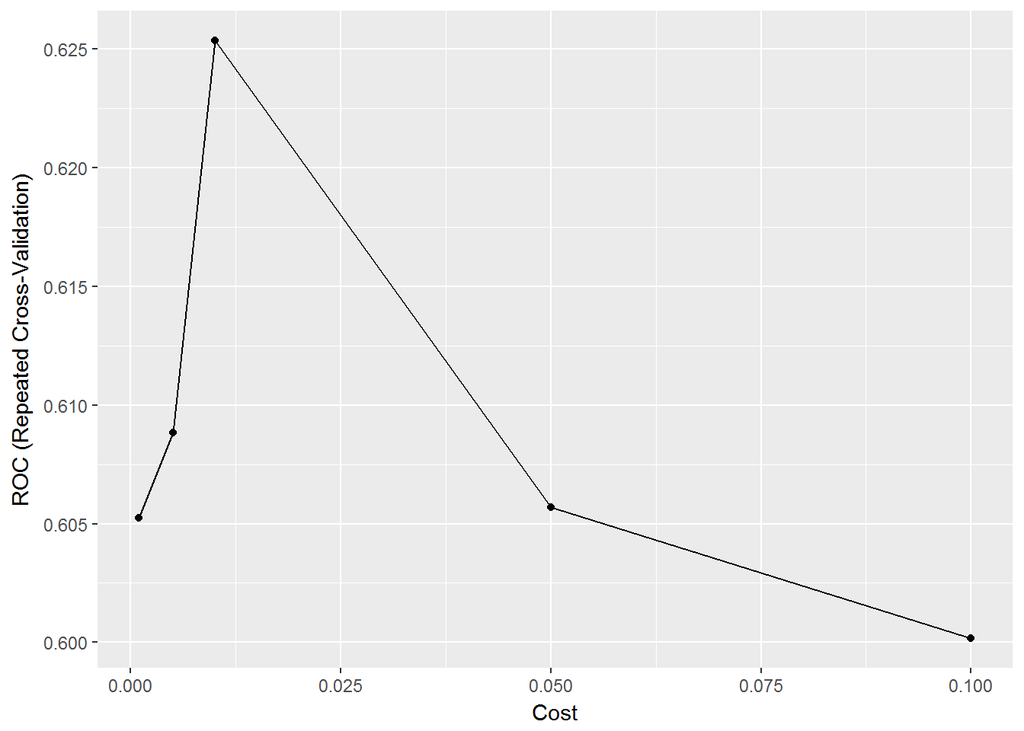

```r
ggplot(svmFit2)
```

#### 建立glm模型

```r
glmFit2 =  train(x=DATAT[,-y],y = DATAT[,y],
                 method="glm",
                 metric = "ROC",
                 trControl = fitControl)
glmFit2
```

```
## Generalized Linear Model
##
## 216 samples
##   5 predictor
##   2 classes: 'X0', 'X1'
##
## No pre-processing
## Resampling: Cross-Validated (10 fold, repeated 5 times)
## Summary of sample sizes: 194, 194, 194, 194, 195, 194, ...
## Resampling results:
##
##   ROC        Sens       Spec
##   0.6238248  0.7978205  0.3533333
```

#### 重抽样

- **resample**收集重抽样结果，使模型能在相同的训练集下计算预测能力。

```r
set.seed(1994)
resamps <- resamples(list(GBM = gbmFit1,
                          SVM1 = svmFit1,
                          SVM2 = svmFit2,
                          GLM = glmFit2))
summary(resamps)
```

```
##
## Call:
## summary.resamples(object = resamps)
##
## Models: GBM, SVM1, SVM2, GLM
## Number of resamples: 50
##
## ROC
##        Min. 1st Qu. Median   Mean 3rd Qu.   Max. NA's
## GBM  0.4145  0.5926 0.6444 0.6510  0.7167 0.9573    0
## SVM1 0.4359  0.5873 0.6514 0.6526  0.7201 0.8803    0
## SVM2 0.3889  0.5480 0.6132 0.6253  0.7153 0.9402    0
## GLM  0.2991  0.5339 0.6246 0.6238  0.6956 0.9188    0
##
## Sens
##        Min. 1st Qu. Median   Mean 3rd Qu. Max. NA's
## GBM  0.4615  0.7548 0.8333 0.8224  0.9167    1    0
## SVM1 0.3846  0.6667 0.7692 0.7596  0.8462    1    0
## SVM2 0.4615  0.7500 0.8462 0.8464  1.0000    1    0
## GLM  0.3846  0.7548 0.8333 0.7978  0.8990    1    0
##
## Spec
##      Min. 1st Qu. Median   Mean 3rd Qu.   Max. NA's
## GBM     0 0.11110 0.2222 0.2444  0.3333 0.5556    0
## SVM1    0 0.33330 0.4444 0.4178  0.5556 1.0000    0
## SVM2    0 0.02778 0.2222 0.2244  0.3333 0.6667    0
## GLM     0 0.22220 0.3333 0.3533  0.4444 0.6667    0
```

- 模型比较的可视化

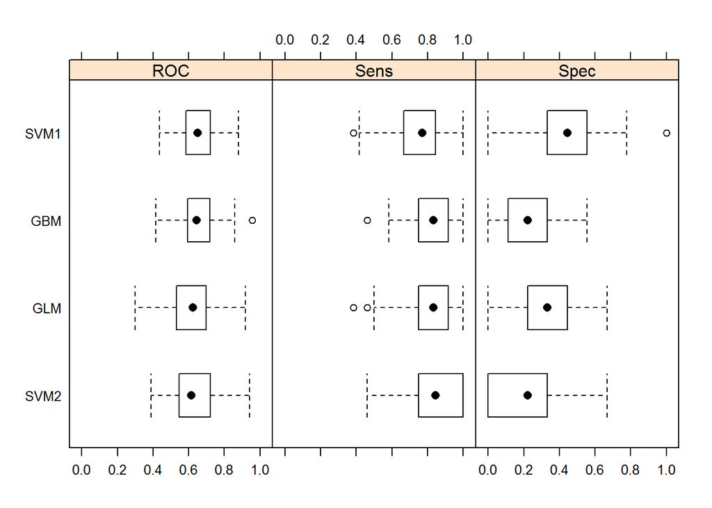

```r
trellis.par.set(caretTheme())
bwplot(resamps, layout = c(3, 1))
```

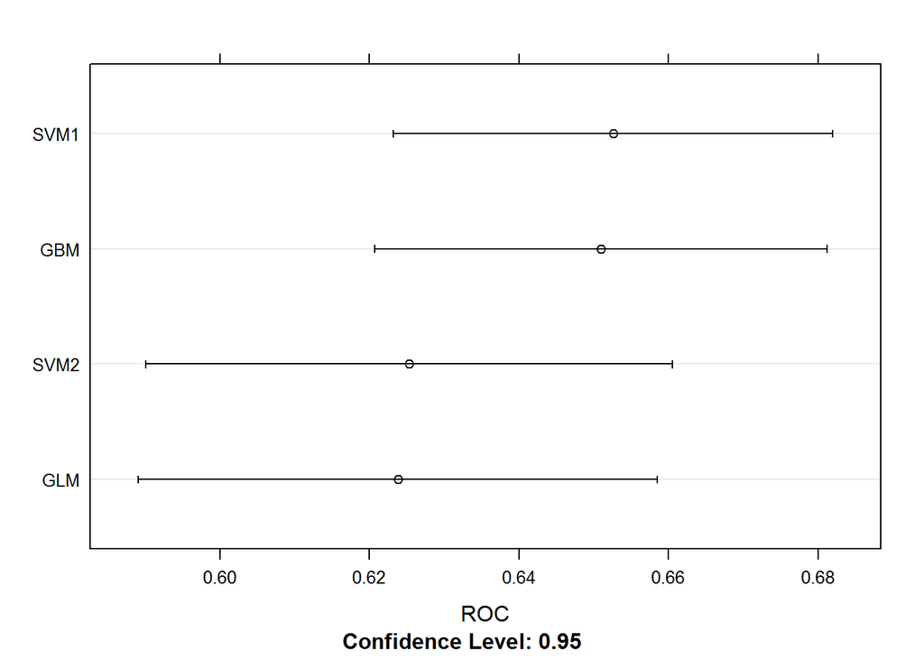

```r
dotplot(resamps, metric = "ROC")
```

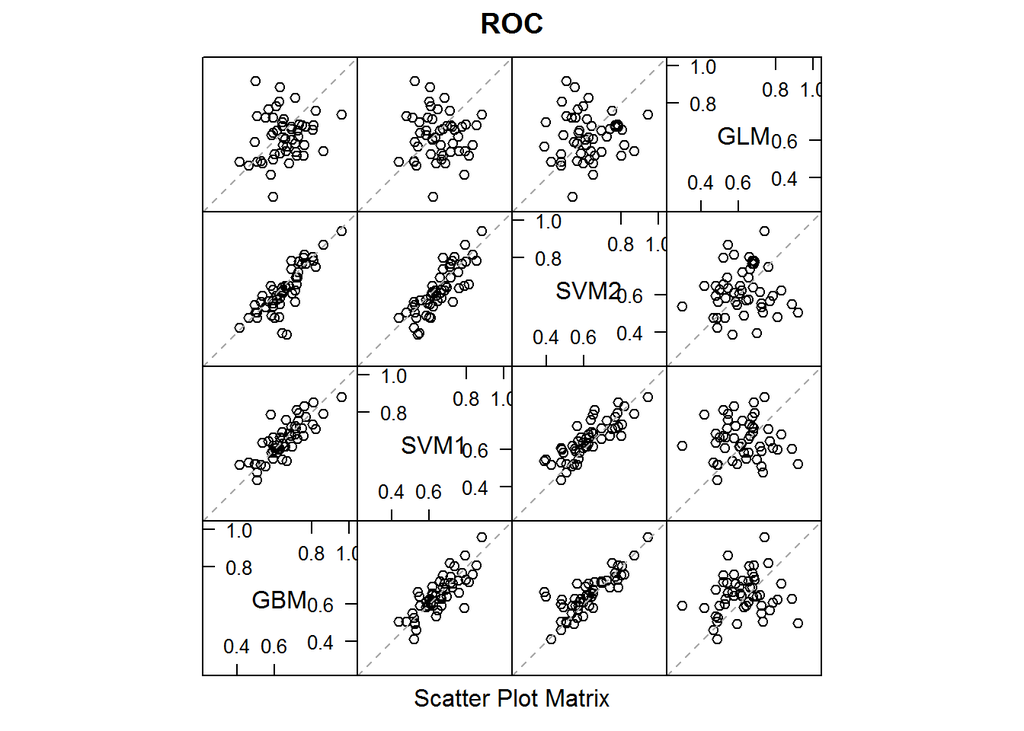

```r
splom(resamps)
```

### 模型检验

- **extractPrediction**得到预测结果
- **extractProb**得到预测概率
- **confusionMatrix**观察混淆矩阵知分类问题的效能检验

```r
models = list(gbmFit1,svmFit1,svmFit2,glmFit2)#自动选择最优模型
predValues = extractPrediction(models,testX = DATA[,-y], testY = DATA[,y])
head(predValues)
```

```
##   obs pred model dataType  object
## 1  X0   X0   gbm Training Object1
## 2  X0   X0   gbm Training Object1
## 3  X1   X0   gbm Training Object1
## 4  X0   X0   gbm Training Object1
## 5  X0   X0   gbm Training Object1
## 6  X1   X0   gbm Training Object1
```

```r
testValues = subset(predValues, dataType == "Test")
probValues = extractProb(models,testX = DATA[,-y], testY = DATA[,y])
testProbs = subset(probValues, dataType == "Test")
Pred1 = subset(testValues, model == "gbm")
Pred2 = subset(testValues, model == "svmRadial")
Pred3 = subset(testValues, model == "svmLinear")
Pred4 = subset(testValues, model == "glm")
confusionMatrix(Pred1$pred, Pred1$obs)
```

```
## Confusion Matrix and Statistics
##
##           Reference
## Prediction X0 X1
##         X0 53 27
##         X1  8 16
##
##                Accuracy : 0.6635
##                  95% CI : (0.5642, 0.7532)
##     No Information Rate : 0.5865
##     P-Value [Acc > NIR] : 0.066514
##
##                   Kappa : 0.2577
##  Mcnemar's Test P-Value : 0.002346
##
##             Sensitivity : 0.8689
##             Specificity : 0.3721
##          Pos Pred Value : 0.6625
##          Neg Pred Value : 0.6667
##              Prevalence : 0.5865
##          Detection Rate : 0.5096
##    Detection Prevalence : 0.7692
##       Balanced Accuracy : 0.6205
##
##        'Positive' Class : X0
##
```

```r
confusionMatrix(Pred2$pred, Pred2$obs)
```

```
## Confusion Matrix and Statistics
##
##           Reference
## Prediction X0 X1
##         X0 51 22
##         X1 10 21
##
##                Accuracy : 0.6923
##                  95% CI : (0.5942, 0.7791)
##     No Information Rate : 0.5865
##     P-Value [Acc > NIR] : 0.01713
##
##                   Kappa : 0.3384
##  Mcnemar's Test P-Value : 0.05183
##
##             Sensitivity : 0.8361
##             Specificity : 0.4884
##          Pos Pred Value : 0.6986
##          Neg Pred Value : 0.6774
##              Prevalence : 0.5865
##          Detection Rate : 0.4904
##    Detection Prevalence : 0.7019
##       Balanced Accuracy : 0.6622
##
##        'Positive' Class : X0
##
```

```r
confusionMatrix(Pred3$pred, Pred3$obs)
```

```
## Confusion Matrix and Statistics
##
##           Reference
## Prediction X0 X1
##         X0 52 25
##         X1  9 18
##
##                Accuracy : 0.6731
##                  95% CI : (0.5741, 0.7619)
##     No Information Rate : 0.5865
##     P-Value [Acc > NIR] : 0.04397
##
##                   Kappa : 0.2868
##  Mcnemar's Test P-Value : 0.01010
##
##             Sensitivity : 0.8525
##             Specificity : 0.4186
##          Pos Pred Value : 0.6753
##          Neg Pred Value : 0.6667
##              Prevalence : 0.5865
##          Detection Rate : 0.5000
##    Detection Prevalence : 0.7404
##       Balanced Accuracy : 0.6355
##
##        'Positive' Class : X0
##
```

```r
confusionMatrix(Pred4$pred, Pred4$obs)
```

```
## Confusion Matrix and Statistics
##
##           Reference
## Prediction X0 X1
##         X0 53 25
##         X1  8 18
##
##                Accuracy : 0.6827
##                  95% CI : (0.5842, 0.7705)
##     No Information Rate : 0.5865
##     P-Value [Acc > NIR] : 0.027988
##
##                   Kappa : 0.3053
##  Mcnemar's Test P-Value : 0.005349
##
##             Sensitivity : 0.8689
##             Specificity : 0.4186
##          Pos Pred Value : 0.6795
##          Neg Pred Value : 0.6923
##              Prevalence : 0.5865
##          Detection Rate : 0.5096
##    Detection Prevalence : 0.7500
##       Balanced Accuracy : 0.6437
##
##        'Positive' Class : X0
##
```

- 用ROCR包画出ROC曲线并计算AUC

```r
library(ROCR)
```

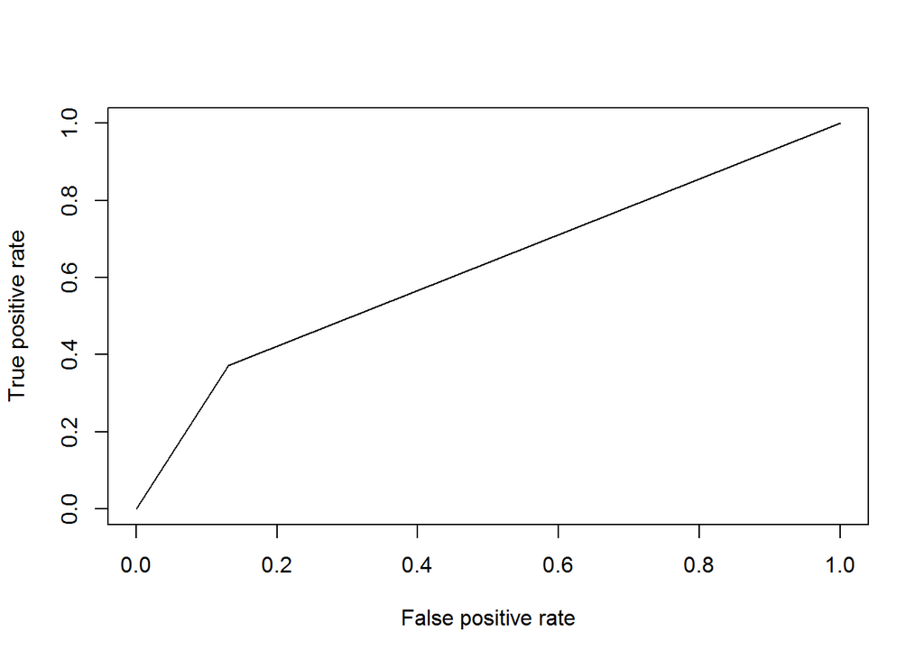

```r
p1 = prediction(as.numeric(Pred1$pred), as.numeric(Pred1$obs))
perf1 = performance(p1, measure="tpr", x.measure="fpr")
plot(perf1)
```

```r
performance(p1,'auc')@y.values
```

```
## [[1]]
## [1] 0.6204727
```

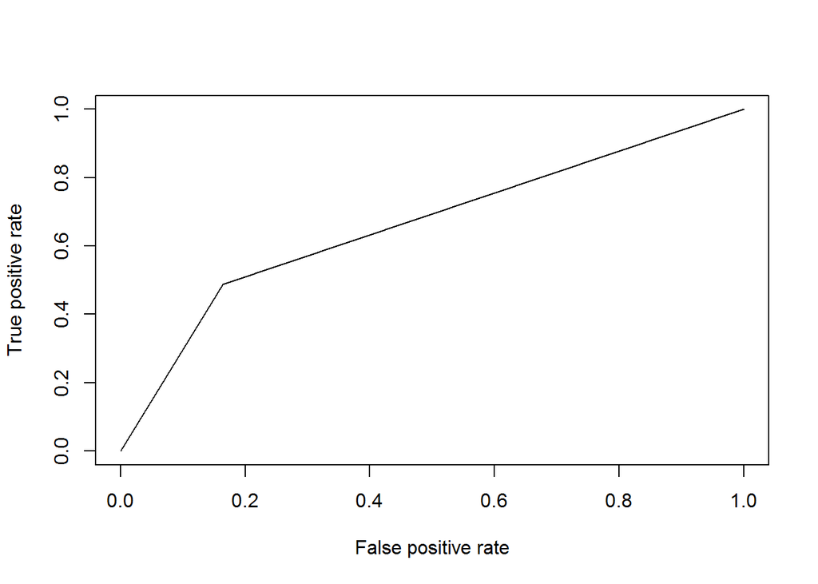

```r
p2 = prediction(as.numeric(Pred2$pred), as.numeric(Pred2$obs))
perf2 = performance(p2, measure="tpr", x.measure="fpr")
plot(perf2)
```

```r
performance(p2,'auc')@y.values
```

```
## [[1]]
## [1] 0.6622188
```